# RegularizedRegression

## Regularized regression

### Introduction

In this notebook I give an example of the application of the regularized regression techniques ridge regression and the lasso. Both techniques aim at adjusting the bias-variance trade off in least squares regression. The application of regularized regression has two main advantages. First, it helps prevent overfitting. This increases the performance of the fitted model on unseen data. Second, in the case of the lasso, it allows for feature selection. This helps reduce model complexity, which leads to increased interpretability of the results.

### Preliminaries

We load the required packages.

The languageR package contains the data set that we will use in this example. The dataset in question is the *english* dataset. This dataset contains average response times for 2,284 words in a word naming task (Balota & Spieler, 1998). In the word naming task, participants are presented with a word on the screen. They are asked to read this word aloud as quickly as possible, while retaining accuracy. The response variable of interest in the analyses below is the response time: the time from the moment the word appeared on the screen until the start of the pronunciation.

The glmnet package provides an implementation of ridge regression and the lasso, as well as cross validation methods for optimizing the $\lambda$ parameter in both models.

```r
library(languageR)
suppressMessages(library(glmnet))
set.seed(5)
```

### Data preprocessing

The *english* dataset consists of response times for two groups of participants: old and young. We limit the data to the young participants for the current analyses. Furthermore, we select a subset of the columns in this dataframe that correspond to properties of words that we are interested in.

For regularized regression it is important to standardize all preidctors prior to analysis. The reason for this is that the penalty term depends on the size of the estimated coefficients. The estimated coefficients, in turn, are sensitive to the scale a predictor is on. To prevent predictors with large scales from dominating the penalty term, we have to ensure all predictors are on the same scale.

```r
# Restrict data to young participants
english = english[english$AgeSubject == "young", ]

# Subset columns
english = english[,c(4, 2, 7:29)]

# Scale columns
for(i in 2:ncol(english)) {
  english[,i] = scale(as.numeric(english[,i]))
}

# Inspect data
dim(english)
head(english)
```

1. 2284

2. 25

A data.frame: 6 × 25

|  | Word <fct> | RTnaming <dbl[,1]> | WrittenFrequency <dbl[,1]> | WrittenSpokenFrequencyRatio <dbl[,1]> | FamilySize <dbl[,1]> | DerivationalEntropy <dbl[,1]> | InflectionalEntropy <dbl[,1]> | NumberSimplexSynsets <dbl[,1]> | NumberComplexSynsets <dbl[,1]> | LengthInLetters <dbl[,1]> | ⋯ | ConphonV <dbl[,1]> | ConphonN <dbl[,1]> | ConfriendsV <dbl[,1]> | ConfriendsN <dbl[,1]> | ConffV <dbl[,1]> | ConffN <dbl[,1]> | ConfbV <dbl[,1]> | ConfbN <dbl[,1]> | NounFrequency <dbl[,1]> | VerbFrequency <dbl[,1]> |
| --- | --- | --- | --- | --- | --- | --- | --- | --- | --- | --- | --- | --- | --- | --- | --- | --- | --- | --- | --- | --- | --- |
| 1 | doe | -0.1442994 | -0.601554056 | 0.2952681 | -0.5301349 | -0.7166231 | -1.9385964 | -1.5157577 | -1.1975603 | -1.5944291 | ⋯ | 1.9212296 | 1.2724237 | -0.34923095 | -0.9485028 | 0.4101320 | 0.5800434 | 1.7230804 | 1.5788139 | -0.29660586 | -0.12855777 |
| 2 | whore | 2.1279487 | -0.270835705 | -0.2807770 | -0.5301349 | -0.2042139 | -0.3120086 | -0.9100445 | -1.1975603 | 0.7810934 | ⋯ | 1.6677733 | 1.7460285 | 1.38383476 | 1.2547858 | -0.5970302 | -0.5419879 | 1.2326174 | 1.8281642 | -0.24656063 | -0.12855777 |
| 3 | stress | -0.1730216 | 0.805223267 | 1.2116496 | -0.2582079 | -0.8591942 | 0.5736908 | 1.1609024 | 0.2888402 | 1.9688547 | ⋯ | -0.4443623 | 0.3649538 | -0.06038667 | 0.6876704 | -0.5970302 | -0.5419879 | -0.1516532 | 0.6154424 | -0.01893554 | -0.05953798 |
| 4 | pork | -0.4380459 | -0.002096275 | -1.0333247 | 0.1518235 | -0.1983116 | -1.9759384 | -0.9100445 | 0.8183067 | -0.4066678 | ⋯ | -1.0357602 | -1.2567644 | -0.92691952 | -0.8374864 | 0.4101320 | 2.2069515 | -0.4072327 | -0.4230924 | -0.24225566 | -0.12855777 |
| 5 | plug | 1.0479641 | -0.070939641 | -1.4780911 | 0.4580800 | -0.3259564 | 1.1222341 | 1.1609024 | 0.7005574 | -0.4066678 | ⋯ | -0.1064206 | -0.7854144 | 0.95056833 | -0.2423392 | -0.5970302 | -0.5419879 | -1.3832504 | -1.2421750 | -0.23149325 | -0.11104747 |
| 6 | prop | 0.3618006 | -0.135842038 | 0.2121446 | -0.5301349 | -0.8579204 | 1.1105227 | -0.1469362 | -0.1386272 | -0.4066678 | ⋯ | 0.2315211 | -0.0342085 | 1.23941262 | 0.4666655 | -0.5970302 | -0.5419879 | -0.4072327 | -0.5405204 | -0.25570868 | -0.08770039 |

Next, we split the data into a small data set for training (200 words) and a large data set for testing (2084 words). I use a small data set for training, because the advantages of using regularized regression are more prominent in this case. The reason for this is that for larger data sets the least squares estimates of the coefficients will be closer to the true values of the coefficients for the population. In other words: variance decreases as a function of sample size.

We furthermore define the folds for the cross validation procedure for estimating the $\lambda$ parameter.

```r
# Load sample for training
samp = sample(1:nrow(english), 200)

# Define training data
x.train = as.matrix(english[samp, -c(1,2)])
x.test = as.matrix(english[-samp, -c(1,2)])

# Define test test
y.train = english$RTnaming[samp]
y.test = english$RTnaming[-samp]

# Define cross-validation folds
folds = sample(rep(seq(10), length = nrow(x.train)))

# Inspect data
head(x.train)
```

A matrix: 6 × 23 of type dbl

|  | WrittenFrequency | WrittenSpokenFrequencyRatio | FamilySize | DerivationalEntropy | InflectionalEntropy | NumberSimplexSynsets | NumberComplexSynsets | LengthInLetters | Ncount | MeanBigramFrequency | ⋯ | ConphonV | ConphonN | ConfriendsV | ConfriendsN | ConffV | ConffN | ConfbV | ConfbN | NounFrequency | VerbFrequency |
| --- | --- | --- | --- | --- | --- | --- | --- | --- | --- | --- | --- | --- | --- | --- | --- | --- | --- | --- | --- | --- | --- |
| 834 | -0.3673684 | -0.2178388 | -0.5301349 | -0.6546934 | -0.9608843 | -0.9100445 | 0.2888402 | 0.7810934 | -0.87157507 | 0.176791901 | ⋯ | -0.7823040 | -0.4973405 | -0.63807524 | 0.03009355 | -0.5970302 | -0.5419879 | -0.1516532 | -1.0208276 | -0.27561915 | -0.12855777 |
| 3707 | 1.3049410 | 0.1418555 | 0.3145474 | 0.7330201 | 1.8857150 | 1.0309185 | 0.2888402 | -0.4066678 | -0.05430012 | -0.368294989 | ⋯ | 1.9212296 | 1.2724237 | 0.80614619 | 0.99825044 | 3.1299129 | 2.6475502 | 1.5112737 | 1.4994627 | -0.32297378 | 0.76330051 |
| 889 | -0.8107257 | -0.0357353 | -1.3748171 | -0.9703698 | -1.1030103 | -0.9100445 | -1.1975603 | 1.9688547 | -1.07589381 | 0.003076897 | ⋯ | 0.9918900 | 0.6588759 | -1.36018595 | -1.26479687 | -0.5970302 | -0.5419879 | 1.6384059 | 1.1899842 | -0.30306331 | -0.12855777 |
| 3285 | 0.3029595 | -0.2996409 | 0.4580800 | 0.0338351 | -0.2365825 | 0.3557104 | 1.9040446 | -0.4066678 | -0.66725633 | -0.205698157 | ⋯ | -1.2047311 | -1.4093891 | -1.07134167 | -0.83748641 | -0.5970302 | -0.5419879 | -0.7674518 | -1.2421750 | -0.09265808 | -0.12841185 |
| 1246 | -0.5802819 | -1.6473150 | -0.2582079 | 0.6116185 | -0.3616979 | -0.4802842 | -0.1386272 | -0.4066678 | 0.76297483 | 0.440111014 | ⋯ | -0.5288477 | 0.3487809 | 0.08403548 | 0.75753920 | 1.7415280 | 0.6779867 | -0.7674518 | 0.4053009 | -0.28853405 | -0.12855777 |
| 2979 | -0.3201760 | 0.9320525 | -0.8807096 | -0.9703698 | 0.9063602 | -0.4802842 | -1.1975603 | 0.7810934 | -0.25861886 | 0.918249721 | ⋯ | -0.6978185 | -0.2335992 | -0.34923095 | -1.20049037 | 0.4101320 | 0.7571470 | -0.4072327 | 0.6135359 | -0.29875834 | -0.09266164 |

### Least squares regression

First, let's fit a regular least squares regression model to the training data.

```r
# Run model
lm = lm(RTnaming ~ ., data = english[samp,-1])

# Show model summary
summary(lm)
```

```
Call:
lm(formula = RTnaming ~ ., data = english[samp, -1])

Residuals:
     Min       1Q   Median       3Q      Max
-2.54037 -0.53765 -0.04511  0.50537  2.87004

Coefficients:
                              Estimate Std. Error t value Pr(>|t|)
(Intercept)                 -0.0453112  0.0603521  -0.751   0.4538
WrittenFrequency            -0.2511359  0.1119972  -2.242   0.0262 *
WrittenSpokenFrequencyRatio  0.0001508  0.0704548   0.002   0.9983
FamilySize                   0.0266075  0.1477522   0.180   0.8573
DerivationalEntropy         -0.0271988  0.0966850  -0.281   0.7788
InflectionalEntropy         -0.1032577  0.0726618  -1.421   0.1571
NumberSimplexSynsets         0.0581958  0.0989583   0.588   0.5572
NumberComplexSynsets        -0.0532810  0.0875386  -0.609   0.5435
LengthInLetters              0.2000774  0.1432001   1.397   0.1641
Ncount                      -0.1222494  0.0884632  -1.382   0.1687
MeanBigramFrequency          0.0028135  0.1418309   0.020   0.9842
FrequencyInitialDiphone     -0.2145383  0.0851941  -2.518   0.0127 *
ConspelV                     0.5393455  0.4059158   1.329   0.1857
ConspelN                     0.1080834  0.2118934   0.510   0.6106
ConphonV                    -0.2861670  0.1728913  -1.655   0.0997 .
ConphonN                    -0.2384314  0.1596747  -1.493   0.1372
ConfriendsV                 -0.2196559  0.3975368  -0.553   0.5813
ConfriendsN                 -0.0640560  0.2133244  -0.300   0.7643
ConffV                      -0.0488445  0.1827456  -0.267   0.7896
ConffN                      -0.1007721  0.1353726  -0.744   0.4576
ConfbV                       0.3522579  0.1671327   2.108   0.0365 *
ConfbN                       0.0764538  0.1387928   0.551   0.5824
NounFrequency               -0.0212975  0.0952896  -0.224   0.8234
VerbFrequency               -0.0135698  0.0290669  -0.467   0.6412
---
Signif. codes:  0 ‘***’ 0.001 ‘**’ 0.01 ‘*’ 0.05 ‘.’ 0.1 ‘ ’ 1

Residual standard error: 0.8241 on 176 degrees of freedom
Multiple R-squared:  0.3313,	Adjusted R-squared:  0.2439
F-statistic: 3.791 on 23 and 176 DF,  p-value: 2.111e-07
```

We can replicate this in the glmnet package by setting $\lambda$ - and hence the penalty term - to zero.

Note that unlike the lm() function, the glmnet() function requires the input data to come in the form of a matrix with observations as rows and predictor values as columns and a vector with response variable values. We set the stopping criterion to a very low value through the thres parameter to ensure coefficient estimates are accurate.

```r
# Run model
ls = glmnet(x.train, y.train, alpha = 1, lambda = 0, thres = 1e-100)

# Extract coefficient estimates
ls$beta
```

```
23 x 1 sparse Matrix of class "dgCMatrix"
                                       s0
WrittenFrequency            -0.2511359293
WrittenSpokenFrequencyRatio  0.0001508299
FamilySize                   0.0266074557
DerivationalEntropy         -0.0271988071
InflectionalEntropy         -0.1032576843
NumberSimplexSynsets         0.0581957591
NumberComplexSynsets        -0.0532809845
LengthInLetters              0.2000773984
Ncount                      -0.1222493900
MeanBigramFrequency          0.0028134793
FrequencyInitialDiphone     -0.2145382628
ConspelV                     0.5393454651
ConspelN                     0.1080833586
ConphonV                    -0.2861669839
ConphonN                    -0.2384313751
ConfriendsV                 -0.2196559400
ConfriendsN                 -0.0640559909
ConffV                      -0.0488444772
ConffN                      -0.1007721139
ConfbV                       0.3522579236
ConfbN                       0.0764538475
NounFrequency               -0.0212974881
VerbFrequency               -0.0135698003
```

As expected, the results of the lm() function and the glmnet() function are (nearly) identical.

### Ridge regression

When using regularized regression, we first have to determine the optimal value of the penalty parameter $\lambda$. The higher the value of $\lambda$, the greater the penalty term and the more shrinkage of the coefficient estimates. We set the parameter $\alpha$ to zero, which indicates that we would like to carry out ridge regression.

(The $\alpha$ parameter originates from the elastic net model, which uses a penalty term that is a weighted combination of the penalty terms in ridge regression and the lasso, with the weights for both terms summing up to 1. The value of $\alpha$ corresponds to the weight of the $\ell_1$ norm in the elastic net. When we set $\alpha$ to zero, the contribution of the $\ell_1$ norm to the penalty term in the elastic net is zero. Hence, the penalty term consists of the $\ell_2$ norm only. Therefore, the elastic net with $\alpha$ = 0 is equivalent to ridge regression.)

```r
# Run cross-validation procedure
ridge.cv = cv.glmnet(x.train, y.train, alpha = 0, nfolds = 10, fold.id = folds,
                     thres = 1e-100)

# Show results
ridge.cv
```

```
Call:  cv.glmnet(x = x.train, y = y.train, nfolds = 10, alpha = 0, fold.id = folds,      thres = 1e-100)

Measure: Mean-Squared Error

    Lambda Index Measure      SE Nonzero
min  0.971    64  0.7295 0.06439      23
1se  5.686    45  0.7922 0.05362      23
```

The optimal value of $\lambda$ is the value for which the mean square error (MSE) of the model under cross validation is minimized. Here, this value is 0.971.

Now that we determined the optimal value of $\lambda$, we fit the ridge regression model itself.

```r
# Run model
ridge = glmnet(x.train, y.train, alpha = 0, lambda = ridge.cv$lambda.min,
               thres = 1e-100)

# Extract coefficient estimates
ridge$beta
```

```
23 x 1 sparse Matrix of class "dgCMatrix"
                                      s0
WrittenFrequency            -0.079870111
WrittenSpokenFrequencyRatio -0.002597172
FamilySize                  -0.035614372
DerivationalEntropy         -0.007978164
InflectionalEntropy         -0.019285272
NumberSimplexSynsets        -0.019438026
NumberComplexSynsets        -0.044929257
LengthInLetters              0.107936100
Ncount                      -0.084889931
MeanBigramFrequency          0.034984694
FrequencyInitialDiphone     -0.127830468
ConspelV                     0.026601156
ConspelN                    -0.013137916
ConphonV                     0.004041418
ConphonN                    -0.027869400
ConfriendsV                  0.021305031
ConfriendsN                 -0.013692645
ConffV                       0.003123468
ConffN                      -0.004690780
ConfbV                       0.052156333
ConfbN                       0.013768859
NounFrequency               -0.040878060
VerbFrequency               -0.010304874
```

The coefficient estimates were shrunk considerably as compared to the coefficient estimates in the least squares regression model. Note that, as is true by definition for ridge regression, none of the coefficients were shrunk to zero.

We will look at the impact of the regularization on the performance of the model below, after fitting the lasso to the data as well.

### Lasso

The procedure for fitting the lasso to the data is nearly identical as the procedure for fitting a ridge regression model. The only difference is that this time we set $\alpha$ to 1, rather than 0.

```r
# Run cross-validation procedure
lasso.cv = cv.glmnet(x.train, y.train, alpha = 1, nfolds = 10, fold.id = folds)

# Show results
lasso.cv
```

```
Call:  cv.glmnet(x = x.train, y = y.train, nfolds = 10, alpha = 1, fold.id = folds)

Measure: Mean-Squared Error

    Lambda Index Measure      SE Nonzero
min 0.0582    20  0.6998 0.07176       6
1se 0.1951     7  0.7640 0.07514       4
```

We fit the lasso to the data using this value of $\lambda$.

```r
# Run model
lasso = glmnet(x.train, y.train, alpha = 1, lambda = lasso.cv$lambda.min,
               thres = 1e-100)

# Extract coefficient estimates
lasso$beta
```

```
23 x 1 sparse Matrix of class "dgCMatrix"
                                     s0
WrittenFrequency            -0.17818867
WrittenSpokenFrequencyRatio  .
FamilySize                  -0.01055107
DerivationalEntropy          .
InflectionalEntropy          .
NumberSimplexSynsets         .
NumberComplexSynsets         .
LengthInLetters              0.19060612
Ncount                      -0.05723671
MeanBigramFrequency          .
FrequencyInitialDiphone     -0.18182443
ConspelV                     .
ConspelN                     .
ConphonV                     .
ConphonN                     .
ConfriendsV                  .
ConfriendsN                  .
ConffV                       .
ConffN                       .
ConfbV                       0.03738086
ConfbN                       .
NounFrequency                .
VerbFrequency                .
```

Unlike ridge regression, the lasso shrinks coefficient estimates for model terms it deems irrelevant to exactly zero. According to the lasso, no less than 17 model terms do not contribute to the predictive power of the model. Hence, we are left with non-zero coefficient estimates for 6 model terms.

### Model comparison

Above, we fitted regression models to the word naming data using least squares regression, ridge regression, and the lasso. We will now take a closer look at the results of these models. First, let's put the coefficient estimates for the three models side-by-side.

```r
# Combine coefficients
coefs = cbind(ls$beta, ridge$beta, lasso$beta)
coefs = as.matrix(coefs)
colnames(coefs) = c("least squares", "ridge regression", "lasso")

# Show coefficient estimates
coefs
```

A matrix: 23 × 3 of type dbl

|  | least squares | ridge regression | lasso |
| --- | --- | --- | --- |
| WrittenFrequency | -0.2511359293 | -0.079870111 | -0.17818867 |
| WrittenSpokenFrequencyRatio | 0.0001508299 | -0.002597172 | 0.00000000 |
| FamilySize | 0.0266074557 | -0.035614372 | -0.01055107 |
| DerivationalEntropy | -0.0271988071 | -0.007978164 | 0.00000000 |
| InflectionalEntropy | -0.1032576843 | -0.019285272 | 0.00000000 |
| NumberSimplexSynsets | 0.0581957591 | -0.019438026 | 0.00000000 |
| NumberComplexSynsets | -0.0532809845 | -0.044929257 | 0.00000000 |
| LengthInLetters | 0.2000773984 | 0.107936100 | 0.19060612 |
| Ncount | -0.1222493900 | -0.084889931 | -0.05723671 |
| MeanBigramFrequency | 0.0028134793 | 0.034984694 | 0.00000000 |
| FrequencyInitialDiphone | -0.2145382628 | -0.127830468 | -0.18182443 |
| ConspelV | 0.5393454651 | 0.026601156 | 0.00000000 |
| ConspelN | 0.1080833586 | -0.013137916 | 0.00000000 |
| ConphonV | -0.2861669839 | 0.004041418 | 0.00000000 |
| ConphonN | -0.2384313751 | -0.027869400 | 0.00000000 |
| ConfriendsV | -0.2196559400 | 0.021305031 | 0.00000000 |
| ConfriendsN | -0.0640559909 | -0.013692645 | 0.00000000 |
| ConffV | -0.0488444772 | 0.003123468 | 0.00000000 |
| ConffN | -0.1007721139 | -0.004690780 | 0.00000000 |
| ConfbV | 0.3522579236 | 0.052156333 | 0.03738086 |
| ConfbN | 0.0764538475 | 0.013768859 | 0.00000000 |
| NounFrequency | -0.0212974881 | -0.040878060 | 0.00000000 |
| VerbFrequency | -0.0135698003 | -0.010304874 | 0.00000000 |

As noted above, the coefficient estimates for ridge regression are considerably smaller than the coefficient estimates for least squares regression. For the lasso, a large number of coefficients is exactly zero. The lasso thus succeeded in reducing the number of features substantially. Note that the values of the non-zero coefficients in the lasso may be either smaller or greater than the corresponding estimates in ridge regression.

Next, let's take a look at the performance of the models by comparing the performance of least squares regression, ridge regression, and the lasso to a baseline model that always predictors the mean response time in the data. We calculate the root mean square error (RMSE) for each model for the training data as well as the test data.

A matrix: 2 × 4 of type dbl

|  | baseline | least squares | ridge | lasso |
| --- | --- | --- | --- | --- |
| train | 0.9453966 | 0.7730899 | 0.8134058 | 0.8067105 |
| test | 1.0063493 | 0.9052838 | 0.8886266 | 0.8838121 |

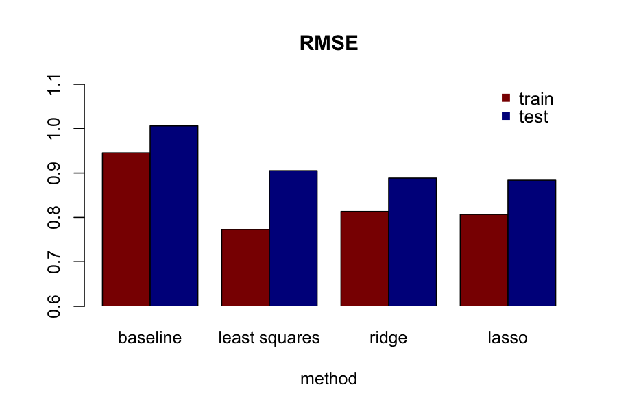

```r
# RMSE for baseline model that always predicts the mean RT
preds.none.train = mean(y.train)
none.train.rmse = sqrt(sum((preds.none.train - y.train)^2) / length(y.train))
preds.none.test = mean(y.train)
none.test.rmse = sqrt(sum((preds.none.test - y.test)^2) / length(y.test))

# RMSE for least squares regression
preds.ls.train = predict(ls, newx = x.train)
ls.train.rmse = sqrt(sum((preds.ls.train - y.train)^2) / length(y.train))
preds.ls.test = predict(ls, newx = x.test)
ls.test.rmse = sqrt(sum((preds.ls.test - y.test)^2) / length(y.test))

# RMSE for ridge regression
preds.ridge.train = predict(ridge, newx = x.train)
ridge.train.rmse = sqrt(sum((preds.ridge.train - y.train)^2) / length(y.train))
preds.ridge.test = predict(ridge, newx = x.test)
ridge.test.rmse = sqrt(sum((preds.ridge.test - y.test)^2) / length(y.test))

# RMSE for the lasso
preds.lasso.train = predict(lasso, newx = x.train)
lasso.train.rmse = sqrt(sum((preds.lasso.train - y.train)^2) / length(y.train))
preds.lasso.test = predict(lasso, newx = x.test)
lasso.test.rmse = sqrt(sum((preds.lasso.test - y.test)^2) / length(y.test))

# Create matrix of RMSE values
preds = matrix(c(none.train.rmse, none.test.rmse, ls.train.rmse, ls.test.rmse,
                 ridge.train.rmse, ridge.test.rmse, lasso.train.rmse,
                 lasso.test.rmse), nrow = 2)
rownames(preds) = c("train", "test")
colnames(preds) = c("baseline", "least squares", "ridge", "lasso")
preds

# Plot RMSE
options(repr.plot.width = 6, repr.plot.height = 4, repr.plot.res = 150)
barplot(preds, beside =  TRUE, col = c("darkred", "darkblue"),
        main = "RMSE", xlab = "method", ylim = c(0.6, 1.1),
        space = rep(c(0.5, 0), 4), xpd = FALSE)
legend(c("train", "test"), x = 10, y = 1.1, xjust = 1, yjust = 1,
       col = c("darkred", "darkblue"), pch = 15, cex = 1.05, y.intersp = 2,
       bty = "n")
```

The RMSE for the training data is the lowest for least squares regression. This is not a suprise. Least squares regression results in estimates with a low bias. Ridge regression and the lasso trade of some bias in return for lower variance. This lower variance results in better performance for the test data. As a consequence, both ridge regression and the lasso perform a better on the test data than does the least squares regression model - although the differences are modest. The extent to which regularized regression helps improve prediction accuracy for unseen data depends on the amount of variance in the least squares estimates. The variance is higher when data sets have fewer observations and more predictors.

### References

Balota, D. A., & Spieler, D. H. (1998). The Utility of Item-Level Analyses in Model Evaluation: A Reply to Seidenberg and Plaut. *Psychological Science*, *9*(3), 238–240